# Final Projecet

```r
# clean up workspace environment
rm(list = ls())
# all packages used for the assignment
library(mosaic)
library(tidyverse)
library(DataComputing)
library(xlsx)
```

### Research question

What is the main reason behind the highest unemployment rate in this decade? We want to investigate what is the main reason that causes unemployment in the year where the unemployment rate is the highest. In addition, we also want to compare it within races. (Research question:What is the main reason behind the highest unemployment rate in this decade? Leading question: Which year has the highest unemployment rate? Is there any difference in unemployment rate between races and sexs?)

### Upoad the data

The raw data consists of number of people employed and unemployed for 3 races the US. The last data (Reason) is a data of reasons why people were uneployed in 2010. The original data in a pdf format and it was not in a proper table so, we had to transfer the table to excel in order to upload it into R.(In the processes, because we do not need all the data, we delete some data and choose what we want to make a new data table.) The data for the latino can be find here “https://www.bls.gov/webapps/legacy/cpsatab3.htm” and the rest of the races here “https://www.bls.gov/webapps/legacy/cpsatab2.htm”

```r
library(readxl)
whiteMenEmploymentLevel <- read_excel("Data/whiteMenEmploymentLevel.xlsx", skip=12)
whiteMenUnemploymentLevel <- read_excel("Data/whiteMenUnemploymentLevel.xlsx", skip=12)
white_women_unemployed <- read_excel("Data/white women unemployed.xlsx", skip = 12)
white_women_employed <- read_excel("Data/white women employed.xlsx", skip = 12)
latino_women_unemployed <- read_excel("Data/latino women unemployed.xlsx", skip = 12)
latino_women_employed <- read_excel("Data/latino women employed.xlsx", skip = 12)
latino_men_unemployed <- read_excel("Data/latino men unemployed.xlsx", skip = 12)
latino_men_employed <- read_excel("Data/latino men employed.xlsx", skip = 12)
black_women_unemployed <- read_excel("Data/black women unemployed.xlsx", skip = 12)
black_women_employed <- read_excel("Data/black women employed.xlsx", skip = 12)
black_men_unemployment <- read_excel("Data/black men unemployment.xlsx", skip = 12)
black_men_employment <- read_excel("Data/black men employment.xlsx", skip = 12)
Reasons <- read_excel("Reason data.xlsx")
```

### View the data

```r
whiteMenEmploymentLevel
```

| Year | Jan | Feb | Mar | Apr | May | Jun | Jul | Aug | Sep | Oct | Nov | Dec |
| --- | --- | --- | --- | --- | --- | --- | --- | --- | --- | --- | --- | --- |
| 2009 | 60779 | 60374 | 59856 | 59912 | 59722 | 59628 | 59597 | 59434 | 59218 | 59113 | 59031 | 58858 |
| 2010 | 58922 | 59069 | 59270 | 59525 | 59595 | 59606 | 59707 | 59742 | 59736 | 59442 | 59122 | 59497 |
| 2011 | 59584 | 59823 | 59828 | 59926 | 60188 | 60010 | 60047 | 60239 | 60287 | 60177 | 60630 | 60706 |
| 2012 | 59939 | 60112 | 60060 | 60025 | 60049 | 60014 | 60092 | 60005 | 60390 | 60585 | 60484 | 60644 |
| 2013 | 60491 | 60464 | 60408 | 60459 | 60511 | 60565 | 60508 | 60496 | 60532 | 60214 | 60770 | 60818 |
| 2014 | 60938 | 60825 | 61081 | 61090 | 61078 | 61258 | 61355 | 61444 | 61576 | 61639 | 61561 | 61753 |
| 2015 | 61826 | 61818 | 61824 | 61837 | 61980 | 62028 | 62079 | 62052 | 61978 | 62049 | 61975 | 62167 |
| 2016 | 62390 | 62613 | 62595 | 62519 | 62439 | 62544 | 62599 | 62641 | 62673 | 62694 | 62675 | 62597 |
| 2017 | 62673 | 62749 | 62753 | 63007 | 62938 | 62901 | 62948 | 63069 | 63235 | 63213 | 63289 | 63370 |
| 2018 | 63502 | 63651 | 63698 | 63724 | 63738 | 63680 | 63681 | 63513 | 63664 | 63785 | 63960 | 64046 |

[output cut: 1 more lines]

```r
black_men_employment
```

| Year | Jan | Feb | Mar | Apr | May | Jun | Jul | Aug | Sep | Oct | Nov | Dec |
| --- | --- | --- | --- | --- | --- | --- | --- | --- | --- | --- | --- | --- |
| 2009 | 6810 | 6740 | 6669 | 6592 | 6651 | 6610 | 6640 | 6596 | 6560 | 6542 | 6567 | 6573 |
| 2010 | 6555 | 6551 | 6565 | 6659 | 6788 | 6645 | 6703 | 6743 | 6694 | 6767 | 6736 | 6756 |
| 2011 | 6695 | 6716 | 6695 | 6707 | 6643 | 6712 | 6708 | 6745 | 6834 | 6885 | 6844 | 7011 |
| 2012 | 7193 | 7054 | 7084 | 7032 | 7103 | 7113 | 7031 | 7085 | 7050 | 7148 | 7192 | 7181 |
| 2013 | 7290 | 7374 | 7349 | 7297 | 7285 | 7229 | 7347 | 7216 | 7281 | 7297 | 7371 | 7338 |
| 2014 | 7392 | 7397 | 7499 | 7525 | 7510 | 7638 | 7683 | 7695 | 7795 | 7767 | 7673 | 7785 |
| 2015 | 7755 | 7813 | 7850 | 8095 | 7971 | 7936 | 7948 | 7967 | 7985 | 7992 | 7903 | 8046 |
| 2016 | 8089 | 8150 | 8120 | 8150 | 8211 | 8244 | 8245 | 8274 | 8265 | 8242 | 8354 | 8394 |
| 2017 | 8430 | 8370 | 8384 | 8499 | 8463 | 8500 | 8516 | 8479 | 8666 | 8536 | 8554 | 8598 |
| 2018 | 8572 | 8889 | 8752 | 8674 | 8790 | 8580 | 8756 | 8828 | 8800 | 8814 | 8771 | 8709 |

[output cut: 1 more lines]

```r
whiteMenUnemploymentLevel
```

| Year | Jan | Feb | Mar | Apr | May | Jun | Jul | Aug | Sep | Oct | Nov | Dec |
| --- | --- | --- | --- | --- | --- | --- | --- | --- | --- | --- | --- | --- |
| 2009 | 4669 | 5052 | 5406 | 5643 | 5933 | 5998 | 5916 | 6029 | 6112 | 6282 | 6249 | 6027 |
| 2010 | 6019 | 6042 | 5925 | 6141 | 5710 | 5701 | 5676 | 5767 | 5680 | 5604 | 5933 | 5560 |
| 2011 | 5215 | 5191 | 5122 | 5212 | 5109 | 5173 | 5075 | 4938 | 4966 | 5051 | 4738 | 4682 |
| 2012 | 4513 | 4451 | 4401 | 4385 | 4476 | 4487 | 4372 | 4332 | 4276 | 4203 | 4107 | 4097 |
| 2013 | 4347 | 4043 | 3940 | 4150 | 4124 | 4022 | 4036 | 4017 | 3936 | 3900 | 3813 | 3583 |
| 2014 | 3454 | 3513 | 3378 | 3232 | 3240 | 3154 | 3045 | 3180 | 2859 | 2719 | 2994 | 2792 |
| 2015 | 2911 | 2897 | 2873 | 2833 | 2803 | 2691 | 2733 | 2643 | 2652 | 2623 | 2657 | 2637 |
| 2016 | 2490 | 2513 | 2581 | 2583 | 2496 | 2588 | 2686 | 2675 | 2712 | 2690 | 2587 | 2592 |
| 2017 | 2552 | 2431 | 2356 | 2218 | 2260 | 2304 | 2246 | 2310 | 2218 | 2122 | 2155 | 2190 |
| 2018 | 2201 | 2236 | 2179 | 2195 | 2106 | 2142 | 1933 | 2014 | 1996 | 1986 | 2000 | 2064 |

[output cut: 1 more lines]

```r
glimpse(whiteMenEmploymentLevel)
```

```
Observations: 11
Variables: 13
$ Year <dbl> 2009, 2010, 2011, 2012, 2013, 2014, 2015, 2016, 2017, 2018, 2019
$ Jan  <dbl> 60779, 58922, 59584, 59939, 60491, 60938, 61826, 62390, 62673, 63502, 63890
$ Feb  <dbl> 60374, 59069, 59823, 60112, 60464, 60825, 61818, 62613, 62749, 63651, 64088
$ Mar  <dbl> 59856, 59270, 59828, 60060, 60408, 61081, 61824, 62595, 62753, 63698, 63936
$ Apr  <dbl> 59912, 59525, 59926, 60025, 60459, 61090, 61837, 62519, 63007, 63724, 63896
$ May  <dbl> 59722, 59595, 60188, 60049, 60511, 61078, 61980, 62439, 62938, 63738, 64042
$ Jun  <dbl> 59628, 59606, 60010, 60014, 60565, 61258, 62028, 62544, 62901, 63680, 64009
$ Jul  <dbl> 59597, 59707, 60047, 60092, 60508, 61355, 62079, 62599, 62948, 63681, 64005
$ Aug  <dbl> 59434, 59742, 60239, 60005, 60496, 61444, 62052, 62641, 63069, 63513, 64094
$ Sep  <dbl> 59218, 59736, 60287, 60390, 60532, 61576, 61978, 62673, 63235, 63664, 64246
$ Oct  <dbl> 59113, 59442, 60177, 60585, 60214, 61639, 62049, 62694, 63213, 63785, 64168
$ Nov  <dbl> 59031, 59122, 60630, 60484, 60770, 61561, 61975, 62675, 63289, 63960, NA
$ Dec  <dbl> 58858, 59497, 60706, 60644, 60818, 61753, 62167, 62597, 63370, 64046, NA
```

### Create function that can help data wrangling

```r
employment<-function(x){       # function that help calculate mean employment
  x <-
    x %>%
    filter(Year != "2019") %>%
  mutate (total= Jan+Feb+Mar+ Apr+May+Jun+Jul+Aug+Sep+Oct+Nov+Dec)%>%
  mutate(Employment_Mean=total/12)%>%
    select(Year,Employment_Mean)
  return(x)
}
unemployment <-function(y){   # function that help calculate mean unemployment
  y <-
    y %>%
    filter(Year != "2019") %>%
  mutate (total= Jan+Feb+Mar+ Apr+May+Jun+Jul+Aug+Sep+Oct+Nov+Dec)%>%
  mutate(UnEmployment_Mean=total/12)%>%
    select(Year,UnEmployment_Mean)
  return(y)
}
```

### Find out mean employment and unemployment

From the function we have created, we find the mean employment and unemployment rate of each year of different sex and race

```r
whiteMenEmploymentLevel<-
  employment(whiteMenEmploymentLevel)%>%
  mutate(Race="White") %>%
  mutate(Sex="Men")
  whiteMenEmploymentLevel
```

| Year | Employment_Mean | Race | Sex |
| --- | --- | --- | --- |
| 2009 | 59626.83 | White | Men |
| 2010 | 59436.08 | White | Men |
| 2011 | 60120.42 | White | Men |
| 2012 | 60199.92 | White | Men |
| 2013 | 60519.67 | White | Men |
| 2014 | 61299.83 | White | Men |
| 2015 | 61967.75 | White | Men |
| 2016 | 62581.58 | White | Men |
| 2017 | 63012.08 | White | Men |
| 2018 | 63720.17 | White | Men |

```r
whiteMenUnemploymentLevel<-
unemployment(whiteMenUnemploymentLevel)%>%
  mutate(Race="White") %>%
  mutate(Sex="Men")
whiteMenUnemploymentLevel
```

| Year | UnEmployment_Mean | Race | Sex |
| --- | --- | --- | --- |
| 2009 | 5776.333 | White | Men |
| 2010 | 5813.167 | White | Men |
| 2011 | 5039.333 | White | Men |
| 2012 | 4341.667 | White | Men |
| 2013 | 3992.583 | White | Men |
| 2014 | 3130.000 | White | Men |
| 2015 | 2746.083 | White | Men |
| 2016 | 2599.417 | White | Men |
| 2017 | 2280.167 | White | Men |
| 2018 | 2087.667 | White | Men |

```r
white_women_employed<-
employment(white_women_employed)%>%
  mutate(Race="White") %>%
  mutate(Sex="Women")
white_women_employed
```

| Year | Employment_Mean | Race | Sex |
| --- | --- | --- | --- |
| 2009 | 51233.33 | White | Women |
| 2010 | 51001.00 | White | Women |
| 2011 | 50885.08 | White | Women |
| 2012 | 50915.83 | White | Women |
| 2013 | 51202.42 | White | Women |
| 2014 | 51802.00 | White | Women |
| 2015 | 52163.00 | White | Women |
| 2016 | 52771.08 | White | Women |
| 2017 | 53177.75 | White | Women |
| 2018 | 53681.17 | White | Women |

```r
white_women_unemployed<-
unemployment(white_women_unemployed)%>%
  mutate(Race="White") %>%
  mutate(Sex="Women")
white_women_unemployed
```

| Year | UnEmployment_Mean | Race | Sex |
| --- | --- | --- | --- |
| 2009 | 3747.583 | White | Women |
| 2010 | 3962.750 | White | Women |
| 2011 | 3817.750 | White | Women |
| 2012 | 3563.000 | White | Women |
| 2013 | 3101.167 | White | Women |
| 2014 | 2623.000 | White | Women |
| 2015 | 2249.083 | White | Women |
| 2016 | 2100.417 | White | Women |
| 2017 | 1923.667 | White | Women |
| 2018 | 1743.917 | White | Women |

```r
latino_men_employed<-
employment(latino_men_employed)%>%
  mutate(Race="Latino") %>%
  mutate(Sex="Men")
latino_men_employed
```

| Year | Employment_Mean | Race | Sex |
| --- | --- | --- | --- |
| 2009 | 11256.33 | Latino | Men |
| 2010 | 11438.33 | Latino | Men |
| 2011 | 11685.50 | Latino | Men |
| 2012 | 12212.33 | Latino | Men |
| 2013 | 12638.00 | Latino | Men |
| 2014 | 13202.67 | Latino | Men |
| 2015 | 13624.92 | Latino | Men |
| 2016 | 14055.75 | Latino | Men |
| 2017 | 14355.50 | Latino | Men |
| 2018 | 14873.17 | Latino | Men |

```r
latino_men_unemployed<-
unemployment(latino_men_unemployed)%>%
  mutate(Race="Latino") %>%
  mutate(Sex="Men")
latino_men_unemployed
```

| Year | UnEmployment_Mean | Race | Sex |
| --- | --- | --- | --- |
| 2009 | 1472.0000 | Latino | Men |
| 2010 | 1518.5000 | Latino | Men |
| 2011 | 1345.1667 | Latino | Men |
| 2012 | 1194.3333 | Latino | Men |
| 2013 | 1089.9167 | Latino | Men |
| 2014 | 864.5000 | Latino | Men |
| 2015 | 819.4167 | Latino | Men |
| 2016 | 719.8333 | Latino | Men |
| 2017 | 631.7500 | Latino | Men |
| 2018 | 591.1667 | Latino | Men |

```r
latino_women_employed<-
employment(latino_women_employed)%>%
  mutate(Race="Latino") %>%
  mutate(Sex="Women")
latino_women_employed
```

| Year | Employment_Mean | Race | Sex |
| --- | --- | --- | --- |
| 2009 | 7648.917 | Latino | Women |
| 2010 | 7788.083 | Latino | Women |
| 2011 | 7919.417 | Latino | Women |
| 2012 | 8858.750 | Latino | Women |
| 2013 | 9056.333 | Latino | Women |
| 2014 | 9431.500 | Latino | Women |
| 2015 | 9853.000 | Latino | Women |
| 2016 | 10216.500 | Latino | Women |
| 2017 | 10542.167 | Latino | Women |
| 2018 | 11044.500 | Latino | Women |

```r
latino_women_unemployed<-
unemployment(latino_women_unemployed)%>%
  mutate(Race="Latino") %>%
  mutate(Sex="Women")
latino_women_unemployed
```

| Year | UnEmployment_Mean | Race | Sex |
| --- | --- | --- | --- |
| 2009 | 52.90000 | Latino | Women |
| 2010 | 52.70833 | Latino | Women |
| 2011 | 52.49167 | Latino | Women |
| 2012 | 53.53333 | Latino | Women |
| 2013 | 53.45000 | Latino | Women |
| 2014 | 54.31667 | Latino | Women |
| 2015 | 54.58333 | Latino | Women |
| 2016 | 55.00000 | Latino | Women |
| 2017 | 55.77500 | Latino | Women |
| 2018 | 56.59167 | Latino | Women |

```r
black_men_employment<-
employment(black_men_employment)%>%
  mutate(Race="African American") %>%
  mutate(Sex="Men")
black_men_employment
```

| Year | Employment_Mean | Race | Sex |
| --- | --- | --- | --- |
| 2009 | 6629.167 | African American | Men |
| 2010 | 6680.167 | African American | Men |
| 2011 | 6766.250 | African American | Men |
| 2012 | 7105.500 | African American | Men |
| 2013 | 7306.167 | African American | Men |
| 2014 | 7613.250 | African American | Men |
| 2015 | 7938.417 | African American | Men |
| 2016 | 8228.167 | African American | Men |
| 2017 | 8499.583 | African American | Men |
| 2018 | 8744.583 | African American | Men |

```r
black_men_unemployment<-
unemployment(black_men_unemployment)%>%
  mutate(Race="African American") %>%
  mutate(Sex="Men")
black_men_unemployment
```

| Year | UnEmployment_Mean | Race | Sex |
| --- | --- | --- | --- |
| 2009 | 1288.7500 | African American | Men |
| 2010 | 1394.0833 | African American | Men |
| 2011 | 1358.6667 | African American | Men |
| 2012 | 1151.7500 | African American | Men |
| 2013 | 1081.0833 | African American | Men |
| 2014 | 970.6667 | African American | Men |
| 2015 | 833.4167 | African American | Men |
| 2016 | 736.0833 | African American | Men |
| 2017 | 661.2500 | African American | Men |
| 2018 | 581.1667 | African American | Men |

```r
black_women_employed<-
employment(black_women_employed)%>%
  mutate(Race="African American") %>%
  mutate(Sex="Women")
black_women_employed
```

| Year | Employment_Mean | Race | Sex |
| --- | --- | --- | --- |
| 2009 | 7956.583 | African American | Women |
| 2010 | 7944.833 | African American | Women |
| 2011 | 7905.500 | African American | Women |
| 2012 | 8312.083 | African American | Women |
| 2013 | 8406.083 | African American | Women |
| 2014 | 8661.333 | African American | Women |
| 2015 | 9029.750 | African American | Women |
| 2016 | 9217.750 | African American | Women |
| 2017 | 9513.667 | African American | Women |
| 2018 | 9751.083 | African American | Women |

```r
black_women_unemployed<-
unemployment(black_women_unemployed)%>%
  mutate(Race="African American") %>%
  mutate(Sex="Women")
black_women_unemployed
```

| Year | UnEmployment_Mean | Race | Sex |
| --- | --- | --- | --- |
| 2009 | 1030.3333 | African American | Women |
| 2010 | 1165.2500 | African American | Women |
| 2011 | 1203.3333 | African American | Women |
| 2012 | 1119.5000 | African American | Women |
| 2013 | 1071.5833 | African American | Women |
| 2014 | 943.3333 | African American | Women |
| 2015 | 812.7500 | African American | Women |
| 2016 | 724.6667 | African American | Women |
| 2017 | 658.2500 | African American | Women |
| 2018 | 572.3333 | African American | Women |

### join table of employment and unemployment for each race and sex

Then we get table that shows both employment and unemployment for each sex and race. In this case, we can calculate for unemployment rate.

```r
WhiteMen<-
  whiteMenEmploymentLevel %>%
  left_join(whiteMenUnemploymentLevel)
WhiteMen
```

| Year | Employment_Mean | Race | Sex | UnEmployment_Mean |
| --- | --- | --- | --- | --- |
| 2009 | 59626.83 | White | Men | 5776.333 |
| 2010 | 59436.08 | White | Men | 5813.167 |
| 2011 | 60120.42 | White | Men | 5039.333 |
| 2012 | 60199.92 | White | Men | 4341.667 |
| 2013 | 60519.67 | White | Men | 3992.583 |
| 2014 | 61299.83 | White | Men | 3130.000 |
| 2015 | 61967.75 | White | Men | 2746.083 |
| 2016 | 62581.58 | White | Men | 2599.417 |
| 2017 | 63012.08 | White | Men | 2280.167 |
| 2018 | 63720.17 | White | Men | 2087.667 |

```r
WhiteWomen<-
  white_women_employed %>%
  left_join(white_women_unemployed)
WhiteWomen
```

| Year | Employment_Mean | Race | Sex | UnEmployment_Mean |
| --- | --- | --- | --- | --- |
| 2009 | 51233.33 | White | Women | 3747.583 |
| 2010 | 51001.00 | White | Women | 3962.750 |
| 2011 | 50885.08 | White | Women | 3817.750 |
| 2012 | 50915.83 | White | Women | 3563.000 |
| 2013 | 51202.42 | White | Women | 3101.167 |
| 2014 | 51802.00 | White | Women | 2623.000 |
| 2015 | 52163.00 | White | Women | 2249.083 |
| 2016 | 52771.08 | White | Women | 2100.417 |
| 2017 | 53177.75 | White | Women | 1923.667 |
| 2018 | 53681.17 | White | Women | 1743.917 |

```r
LatinoMen<-
  latino_men_employed%>%
  left_join(latino_men_unemployed)
LatinoMen
```

| Year | Employment_Mean | Race | Sex | UnEmployment_Mean |
| --- | --- | --- | --- | --- |
| 2009 | 11256.33 | Latino | Men | 1472.0000 |
| 2010 | 11438.33 | Latino | Men | 1518.5000 |
| 2011 | 11685.50 | Latino | Men | 1345.1667 |
| 2012 | 12212.33 | Latino | Men | 1194.3333 |
| 2013 | 12638.00 | Latino | Men | 1089.9167 |
| 2014 | 13202.67 | Latino | Men | 864.5000 |
| 2015 | 13624.92 | Latino | Men | 819.4167 |
| 2016 | 14055.75 | Latino | Men | 719.8333 |
| 2017 | 14355.50 | Latino | Men | 631.7500 |
| 2018 | 14873.17 | Latino | Men | 591.1667 |

```r
LatinoWomen<-
  latino_women_employed %>%
  left_join(latino_women_unemployed)
LatinoWomen
```

| Year | Employment_Mean | Race | Sex | UnEmployment_Mean |
| --- | --- | --- | --- | --- |
| 2009 | 7648.917 | Latino | Women | 52.90000 |
| 2010 | 7788.083 | Latino | Women | 52.70833 |
| 2011 | 7919.417 | Latino | Women | 52.49167 |
| 2012 | 8858.750 | Latino | Women | 53.53333 |
| 2013 | 9056.333 | Latino | Women | 53.45000 |
| 2014 | 9431.500 | Latino | Women | 54.31667 |
| 2015 | 9853.000 | Latino | Women | 54.58333 |
| 2016 | 10216.500 | Latino | Women | 55.00000 |
| 2017 | 10542.167 | Latino | Women | 55.77500 |
| 2018 | 11044.500 | Latino | Women | 56.59167 |

```r
BlackMen<-
  black_men_employment %>%
  left_join(black_men_unemployment)
BlackMen
```

| Year | Employment_Mean | Race | Sex | UnEmployment_Mean |
| --- | --- | --- | --- | --- |
| 2009 | 6629.167 | African American | Men | 1288.7500 |
| 2010 | 6680.167 | African American | Men | 1394.0833 |
| 2011 | 6766.250 | African American | Men | 1358.6667 |
| 2012 | 7105.500 | African American | Men | 1151.7500 |
| 2013 | 7306.167 | African American | Men | 1081.0833 |
| 2014 | 7613.250 | African American | Men | 970.6667 |
| 2015 | 7938.417 | African American | Men | 833.4167 |
| 2016 | 8228.167 | African American | Men | 736.0833 |
| 2017 | 8499.583 | African American | Men | 661.2500 |
| 2018 | 8744.583 | African American | Men | 581.1667 |

```r
BlackWomen<-
  black_women_employed %>%
  left_join(black_women_unemployed)
BlackWomen
```

| Year | Employment_Mean | Race | Sex | UnEmployment_Mean |
| --- | --- | --- | --- | --- |
| 2009 | 7956.583 | African American | Women | 1030.3333 |
| 2010 | 7944.833 | African American | Women | 1165.2500 |
| 2011 | 7905.500 | African American | Women | 1203.3333 |
| 2012 | 8312.083 | African American | Women | 1119.5000 |
| 2013 | 8406.083 | African American | Women | 1071.5833 |
| 2014 | 8661.333 | African American | Women | 943.3333 |
| 2015 | 9029.750 | African American | Women | 812.7500 |
| 2016 | 9217.750 | African American | Women | 724.6667 |
| 2017 | 9513.667 | African American | Women | 658.2500 |
| 2018 | 9751.083 | African American | Women | 572.3333 |

### join table into one

```r
UnemploymentRate<-
  rbind(WhiteMen,WhiteWomen,LatinoMen,LatinoWomen,BlackMen,BlackWomen)
UnemploymentRate
```

| Year | Employment_Mean | Race | Sex | UnEmployment_Mean |
| --- | --- | --- | --- | --- |
| 2009 | 59626.833 | White | Men | 5776.33333 |
| 2010 | 59436.083 | White | Men | 5813.16667 |
| 2011 | 60120.417 | White | Men | 5039.33333 |
| 2012 | 60199.917 | White | Men | 4341.66667 |
| 2013 | 60519.667 | White | Men | 3992.58333 |
| 2014 | 61299.833 | White | Men | 3130.00000 |
| 2015 | 61967.750 | White | Men | 2746.08333 |
| 2016 | 62581.583 | White | Men | 2599.41667 |
| 2017 | 63012.083 | White | Men | 2280.16667 |
| 2018 | 63720.167 | White | Men | 2087.66667 |

[output cut: 50 more lines]

### calculate Unempolyment rate

Unemployment rate is calculated by using the formula unemployment rate = number of people unemployed/(number of people employed+number of people unemployed)

```r
UnemploymentRate1<-
UnemploymentRate %>%
  mutate(Unemployment_Rate=UnEmployment_Mean/(UnEmployment_Mean+Employment_Mean))%>%
  select(Year, Race,Sex,Unemployment_Rate)
UnemploymentRate1
```

| Year | Race | Sex | Unemployment_Rate |
| --- | --- | --- | --- |
| 2009 | White | Men | 0.088318863 |
| 2010 | White | Men | 0.089091701 |
| 2011 | White | Men | 0.077338132 |
| 2012 | White | Men | 0.067269293 |
| 2013 | White | Men | 0.061888763 |
| 2014 | White | Men | 0.048579980 |
| 2015 | White | Men | 0.042434255 |
| 2016 | White | Men | 0.039879975 |
| 2017 | White | Men | 0.034922470 |
| 2018 | White | Men | 0.031723680 |

[output cut: 50 more lines]

### Graph of unemployment rate for different sex and race

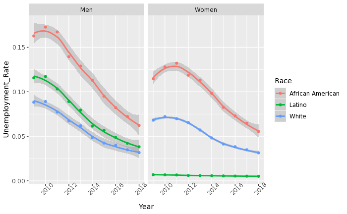

```r
UnemploymentRate1%>%
  ggplot(aes(x=Year, y= Unemployment_Rate, colour = Race), size = 10)+
  stat_smooth()+
  geom_point()+
  facet_wrap(~ Sex)+
  theme(axis.text.x = element_text(angle=45))
```

We can find out that the unemployment rate for male is a little bit higher than that of female. And the race that with the highest unemployment rate is African American. We can almost think 2010 has the highest unemployment rate.

### The year with the highest unemployment rate

Since we want to find the reason behind the highest unemployment rate, we find the year that has the highest unemployment rate. Here we use a more precise way to make sure that 2010 has the highest mean unemployment rate.

```r
UnemploymentRate2<-
UnemploymentRate1%>%
  group_by(Year)%>%
  summarise(mean_rate = mean(Unemployment_Rate))

UnemploymentRate2$Year[which(UnemploymentRate2$mean_rate==max(UnemploymentRate2$mean_rate))]
```

```
[1] 2010
```

### Wrangling second data(The reasons for unemployment)

Because some rows in the dataset are not useful, only some rows are needed. The Total unemployed is the number of unemployment and is not reason so we delete that. On temporary layoff,Not on temporary layoff,Permanent job losers,and Persons who completed temporary jobs are branches of Job losers and persons who completed temporary jobs. So only Job losers and persons who completed temporary jobs is needed. The original data can be found in “https://www.bls.gov/cps/aa2010/cpsaat28.pdf”

```r
Reasons
```

| Reason | White | African American | Hispanic |
| --- | --- | --- | --- |
| Total unemployed | 10916 | 2852 | 2843 |
| Job losers and persons who completed temporary jobs | 7026 | 1613 | 1768 |
| On temporary layoff | 1203 | 154 | 309 |
| Not on temporary layoff | 5823 | 1460 | 1459 |
| Permanent job losers | 4796 | 1157 | 1091 |
| Persons who completed temporary jobs | 1027 | 303 | 368 |
| Job leavers | 672 | 149 | 140 |
| Reentrants | 2394 | 803 | 649 |
| New entrants | 823 | 287 | 285 |

```r
Reasons <-
  Reasons%>%
  filter(Reason %in% c("Job losers and persons who completed temporary jobs","Job leavers","Reentrants","New entrants"))%>%
  rename(Latino = Hispanic)
Reasons
```

| Reason | White | African American | Latino |
| --- | --- | --- | --- |
| Job losers and persons who completed temporary jobs | 7026 | 1613 | 1768 |
| Job leavers | 672 | 149 | 140 |
| Reentrants | 2394 | 803 | 649 |
| New entrants | 823 | 287 | 285 |

### labour force for both gender and reasons’ unemployment rate

One of our limitations is the second data that has the reasons behind unemployment in 2010 is not divided into sex. Hence, we had to to calculate the total labour force during that year in order to be able to find the unemployment rate for the reason data.

```r
UnemploymentRate3 <- # Try to find the total population in each race to prepare for calculation in 2010
UnemploymentRate%>%
  filter(Year =="2010")%>%
  mutate(labor = Employment_Mean+UnEmployment_Mean)%>%
  group_by(Race)%>%
  summarise(total = sum(labor))
UnemploymentRate3
```

| Race | total |
| --- | --- |
| African American | 17184.33 |
| Latino | 20797.62 |
| White | 120213.00 |

### calculate the unemployment rate for different races in different reasons

```r
Reasons <-
  Reasons%>%
gather(key = Race, value = number, White, `African American`, Latino)%>%
  left_join(UnemploymentRate3, by = c("Race"="Race"))%>%
  mutate(rate = number/total)%>%
  select(Reason, Race, rate)%>%
  mutate(Reason = if_else(Reason == "Job losers and persons who completed temporary jobs","Completed temporary jobs",Reason))
Reasons
```

| Reason | Race | rate |
| --- | --- | --- |
| Completed temporary jobs | White | 0.058446258 |
| Job leavers | White | 0.005590078 |
| Reentrants | White | 0.019914651 |
| New entrants | White | 0.006846181 |
| Completed temporary jobs | African American | 0.093864567 |
| Job leavers | African American | 0.008670688 |
| Reentrants | African American | 0.046728609 |
| New entrants | African American | 0.016701259 |
| Completed temporary jobs | Latino | 0.085009707 |
| Job leavers | Latino | 0.006731538 |

[output cut: 2 more lines]

### The plot for reasons

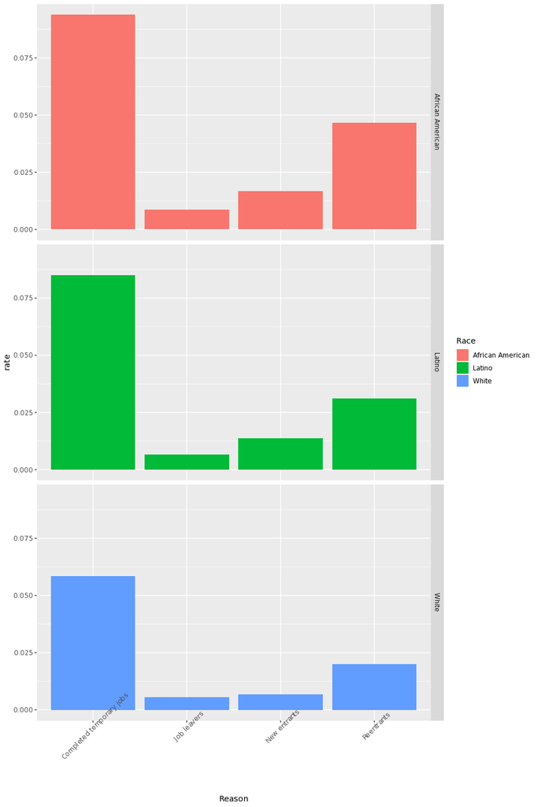

```r
Reasons %>%
  ggplot(aes(x=Reason,y=rate,fill=Race))+
  geom_col()+
  facet_grid(Race~.)+
  theme(axis.text.x = element_text(angle=45))
```